# 2021 경제인문사회연구회 맞춤형

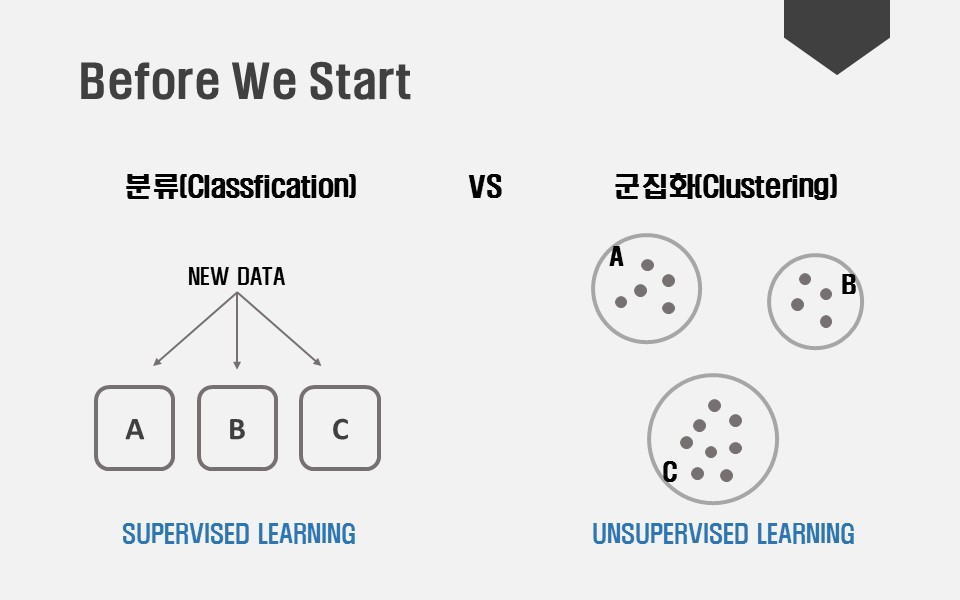

# 기계학습을 통한 분류

## Knn 분류 모형

- 출처 : Machine Learning with R _ Brett Lantz

게으른 분류: 최근접 이웃법

사자성에 `유유상종`이라는 말이 있습니다.

비슷한 것들은 비슷한 특성을 갖는다는 의미이다.

최근접 이웃 분류는 가장 유사학거나 가까운 이웃의 범주로 데이터를 분류한다.

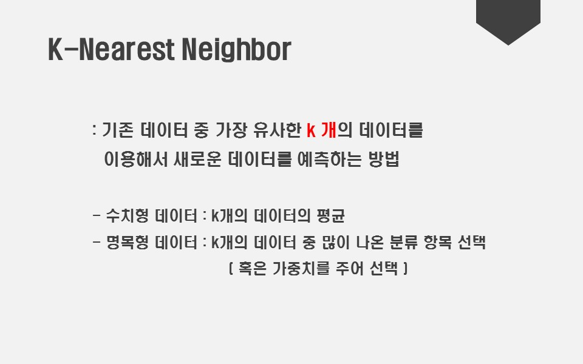

### kNN 알고리즘의 장단점

| 장점 | 단점 |
| --- | --- |
| 단순하며 효율적 | 모델을 생성하지 않음 |
| 데이터의 분산 추정이 필요 없음 | 느린 분류 |
| 빠른 훈련 | 많은 메모리 |
|  | 명목형 자료 및 결측치는 추가적인 처리 필요 |

K에 따라 결과가 달라지는 것을 통해, 분석가의 소신에 따라 K를 정해주는 것이 분석에서의 중요한 요소가 될 것 입니다.

- 너무 작은 k : 과적합의 우려
- 너무 큰 k : 데이터 구조 파악의 어려움

KNN 알고리즘에 대해 조금 더 간단한 데이터를 통해 알아보겠습니다.

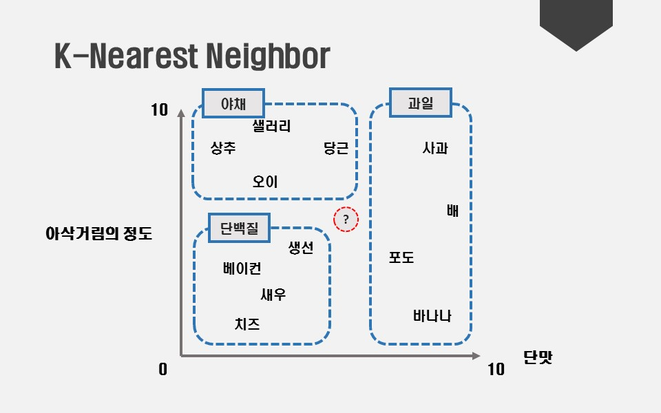

위의 그래프는 여러가지 식품에 대해서 단맛(0~10)과 아삭거림(0~10)의 정도에 따라 2차원 산점도입니다.

위와 같이 데이터들이 분류가 되어있을 때, 새로운 데이터가 입력이 되었을 때, 그 데이터가 어떤 범주로 분류될지

5NN 알고리즘을 통해 분류해보겠습니다.

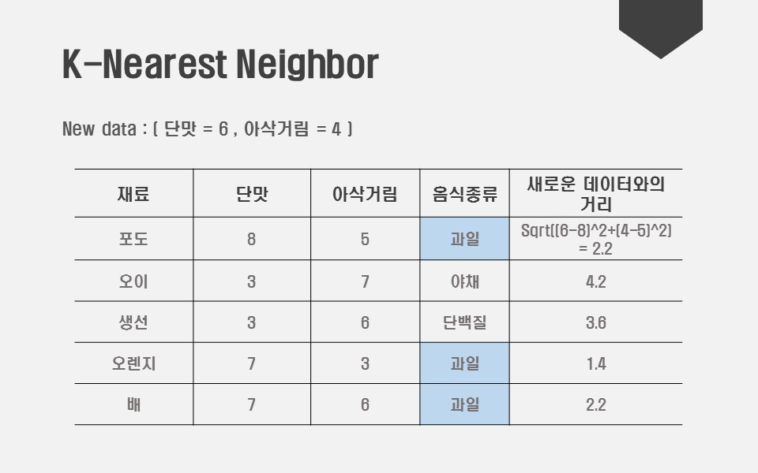

New Data가 단맛=6, 아삭거림=4 일때, 유클리드 거리를 통해 가장 가까운 데이터 5개를 뽑아보았습니다.

그 중 과일인 데이터가 3개임으로 새로운 데이터는 “과일”로 분류가 됩니다.

### R을 이용한 실습

이제 kNN 알고리즘에 대해 위스콘신 대학의 연구자들이 기부한 데이터를 가직고 실습을 해보겠습니다.

이 자료는 유방 암 조직 검사에 대한 569개의 데이터와 32개의 속성을 지니고 있습니다.

```r
wbcd<-read.csv("C:/Users/stats/Documents/advanced2/wisc_bc_data.csv",stringsAsFactors=F)

str(wbcd)
```

```
## 'data.frame':    569 obs. of  32 variables:
##  $ id               : int  87139402 8910251 905520 868871 9012568 906539 925291 87880 862989 89827 ...
##  $ diagnosis        : chr  "B" "B" "B" "B" ...
##  $ radius_mean      : num  12.3 10.6 11 11.3 15.2 ...
##  $ texture_mean     : num  12.4 18.9 16.8 13.4 13.2 ...
##  $ perimeter_mean   : num  78.8 69.3 70.9 73 97.7 ...
##  $ area_mean        : num  464 346 373 385 712 ...
##  $ smoothness_mean  : num  0.1028 0.0969 0.1077 0.1164 0.0796 ...
##  $ compactness_mean : num  0.0698 0.1147 0.078 0.1136 0.0693 ...
##  $ concavity_mean   : num  0.0399 0.0639 0.0305 0.0464 0.0339 ...
##  $ points_mean      : num  0.037 0.0264 0.0248 0.048 0.0266 ...
##  $ symmetry_mean    : num  0.196 0.192 0.171 0.177 0.172 ...
##  $ dimension_mean   : num  0.0595 0.0649 0.0634 0.0607 0.0554 ...
##  $ radius_se        : num  0.236 0.451 0.197 0.338 0.178 ...
##  $ texture_se       : num  0.666 1.197 1.387 1.343 0.412 ...
```

[output cut: 18 more lines]

```r
# M(Malignant) : 악성 / B(Benign) : 양성
# radius : 반지름 / texture : 텍스처 / perimeter : 둘레 / area : 면적 / smmothness : 평활도
# compactness : 다짐도 / concavity : 요면 / concave points : 요면점 / symmetry : 대칭 / fractal dimension : 프렉탈 차원

wbcd<-wbcd[-1] # id 삭제

table(wbcd$diagnosis)
```

```
##
##   B   M
## 357 212
```

```r
wbcd$diagnosis<-factor(wbcd$diagnosis,levels=c("B","M"),labels=c("Benign","Malignant"))
```

- 분석을 전 변수의 요약값을 보면 단위가 다르므로 정규화가 필요합니다.

```r
summary(wbcd) # 단위가 굉장히 다름 -> 정규화가 필요
```

```
##      diagnosis    radius_mean      texture_mean   perimeter_mean
##  Benign   :357   Min.   : 6.981   Min.   : 9.71   Min.   : 43.79
##  Malignant:212   1st Qu.:11.700   1st Qu.:16.17   1st Qu.: 75.17
##                  Median :13.370   Median :18.84   Median : 86.24
##                  Mean   :14.127   Mean   :19.29   Mean   : 91.97
##                  3rd Qu.:15.780   3rd Qu.:21.80   3rd Qu.:104.10
##                  Max.   :28.110   Max.   :39.28   Max.   :188.50
##    area_mean      smoothness_mean   compactness_mean  concavity_mean
##  Min.   : 143.5   Min.   :0.05263   Min.   :0.01938   Min.   :0.00000
##  1st Qu.: 420.3   1st Qu.:0.08637   1st Qu.:0.06492   1st Qu.:0.02956
##  Median : 551.1   Median :0.09587   Median :0.09263   Median :0.06154
##  Mean   : 654.9   Mean   :0.09636   Mean   :0.10434   Mean   :0.08880
##  3rd Qu.: 782.7   3rd Qu.:0.10530   3rd Qu.:0.13040   3rd Qu.:0.13070
##  Max.   :2501.0   Max.   :0.16340   Max.   :0.34540   Max.   :0.42680
##   points_mean      symmetry_mean    dimension_mean      radius_se
##  Min.   :0.00000   Min.   :0.1060   Min.   :0.04996   Min.   :0.1115
##  1st Qu.:0.02031   1st Qu.:0.1619   1st Qu.:0.05770   1st Qu.:0.2324
##  Median :0.03350   Median :0.1792   Median :0.06154   Median :0.3242
##  Mean   :0.04892   Mean   :0.1812   Mean   :0.06280   Mean   :0.4052
##  3rd Qu.:0.07400   3rd Qu.:0.1957   3rd Qu.:0.06612   3rd Qu.:0.4789
##  Max.   :0.20120   Max.   :0.3040   Max.   :0.09744   Max.   :2.8730
##    texture_se      perimeter_se       area_se        smoothness_se
##  Min.   :0.3602   Min.   : 0.757   Min.   :  6.802   Min.   :0.001713
##  1st Qu.:0.8339   1st Qu.: 1.606   1st Qu.: 17.850   1st Qu.:0.005169
##  Median :1.1080   Median : 2.287   Median : 24.530   Median :0.006380
##  Mean   :1.2169   Mean   : 2.866   Mean   : 40.337   Mean   :0.007041
##  3rd Qu.:1.4740   3rd Qu.: 3.357   3rd Qu.: 45.190   3rd Qu.:0.008146
##  Max.   :4.8850   Max.   :21.980   Max.   :542.200   Max.   :0.031130
##  compactness_se      concavity_se       points_se         symmetry_se
##  Min.   :0.002252   Min.   :0.00000   Min.   :0.000000   Min.   :0.007882
##  1st Qu.:0.013080   1st Qu.:0.01509   1st Qu.:0.007638   1st Qu.:0.015160
##  Median :0.020450   Median :0.02589   Median :0.010930   Median :0.018730
##  Mean   :0.025478   Mean   :0.03189   Mean   :0.011796   Mean   :0.020542
##  3rd Qu.:0.032450   3rd Qu.:0.04205   3rd Qu.:0.014710   3rd Qu.:0.023480
##  Max.   :0.135400   Max.   :0.39600   Max.   :0.052790   Max.   :0.078950
##   dimension_se        radius_worst   texture_worst   perimeter_worst
##  Min.   :0.0008948   Min.   : 7.93   Min.   :12.02   Min.   : 50.41
##  1st Qu.:0.0022480   1st Qu.:13.01   1st Qu.:21.08   1st Qu.: 84.11
##  Median :0.0031870   Median :14.97   Median :25.41   Median : 97.66
##  Mean   :0.0037949   Mean   :16.27   Mean   :25.68   Mean   :107.26
##  3rd Qu.:0.0045580   3rd Qu.:18.79   3rd Qu.:29.72   3rd Qu.:125.40
##  Max.   :0.0298400   Max.   :36.04   Max.   :49.54   Max.   :251.20
##    area_worst     smoothness_worst  compactness_worst concavity_worst
##  Min.   : 185.2   Min.   :0.07117   Min.   :0.02729   Min.   :0.0000
##  1st Qu.: 515.3   1st Qu.:0.11660   1st Qu.:0.14720   1st Qu.:0.1145
##  Median : 686.5   Median :0.13130   Median :0.21190   Median :0.2267
##  Mean   : 880.6   Mean   :0.13237   Mean   :0.25427   Mean   :0.2722
##  3rd Qu.:1084.0   3rd Qu.:0.14600   3rd Qu.:0.33910   3rd Qu.:0.3829
##  Max.   :4254.0   Max.   :0.22260   Max.   :1.05800   Max.   :1.2520
##   points_worst     symmetry_worst   dimension_worst
##  Min.   :0.00000   Min.   :0.1565   Min.   :0.05504
##  1st Qu.:0.06493   1st Qu.:0.2504   1st Qu.:0.07146
##  Median :0.09993   Median :0.2822   Median :0.08004
##  Mean   :0.11461   Mean   :0.2901   Mean   :0.08395
##  3rd Qu.:0.16140   3rd Qu.:0.3179   3rd Qu.:0.09208
##  Max.   :0.29100   Max.   :0.6638   Max.   :0.20750
```

```r
# 최대최소 표준화 (0~1값으로 변환)

normalize<-function(x){
  return((x-min(x))/(max(x)-min(x)))
}

wbcd_n<-as.data.frame(lapply(wbcd[2:31],normalize)) # 리스트를 데이터프레임형식으로 변환
```

- 분류모형의 성능 평가를 위헤 데이터를 분할 하겠습니다.
- 일단 샘플링하지 않고 순서대로 훈련데이터와 테스트데이터를 구분하였습니다.

```r
wbcd_train<-wbcd_n[1:469,]
wbcd_test <-wbcd_n[470:569,]


wbcd_train_labels<-wbcd[1:469,1]
wbcd_test_labels<-wbcd[470:569,1]


prop.table(table(wbcd_train_labels))
```

```
## wbcd_train_labels
##    Benign Malignant
## 0.6311301 0.3688699
```

```r
prop.table(table(wbcd_test_labels)) # 데이터 분할이 골고루 잘 되었는지 확인
```

```
## wbcd_test_labels
##    Benign Malignant
##      0.61      0.39
```

- 이제 kNN 알고리즘으로 분류하겠습니다.

  kNN 알고리즘은 class 패키지의 knn함수를 이용합니다.

```r
library(class)
wbcd_test_pred<-knn(train=wbcd_train,
                    test=wbcd_test,
                    cl=wbcd_train_labels, # class : train 데이터의 각 행에 대한 범주인 팩터 벡터
                    k=21)

table(wbcd_test_pred)
```

```
## wbcd_test_pred
##    Benign Malignant
##        63        37
```

위에서는 k를 21로 설정였습니다. 보통 k는 3과 10 사이에서 결정합니다.

최적의 k는 다양한 테스트 데이터 셋애 대해 일부 k값에 따를 분류정확도를 평가하면 된다.

```r
library(caret)
confusionMatrix(wbcd_test_labels,wbcd_test_pred)
```

```
## Confusion Matrix and Statistics
##
##            Reference
## Prediction  Benign Malignant
##   Benign        61         0
##   Malignant      2        37
##
##                Accuracy : 0.98
##                  95% CI : (0.9296, 0.9976)
##     No Information Rate : 0.63
##     P-Value [Acc > NIR] : <2e-16
##
##                   Kappa : 0.9576
##
##  Mcnemar's Test P-Value : 0.4795
##
##             Sensitivity : 0.9683
##             Specificity : 1.0000
##          Pos Pred Value : 1.0000
##          Neg Pred Value : 0.9487
##              Prevalence : 0.6300
##          Detection Rate : 0.6100
##    Detection Prevalence : 0.6100
##       Balanced Accuracy : 0.9841
##
##        'Positive' Class : Benign
##
```

- weighted KNN

앞에서 보았던 KNN 알고리즘은, 단순히 거리의 정도를 생각하지 않고 가장 가까운 데이터 K개 안에서 다수결에 따라 범주를 골라 주었다면, 거리에 대해서 유사성 가중치를 주는 Weighted KNN 에 대해서 알아보겠습니다.

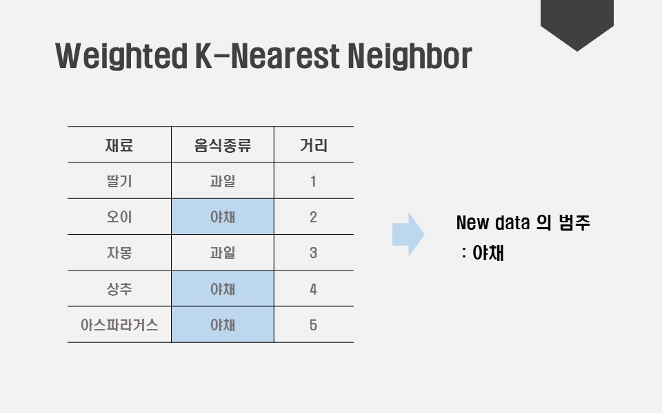

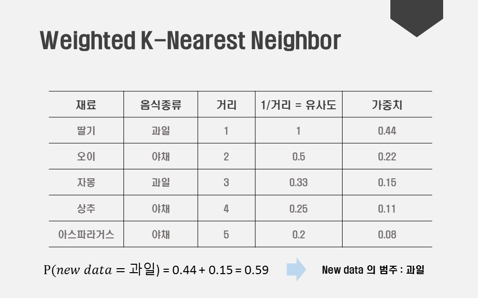

똑같은 데이터에서 유사도를 “1/거리” 로 정의하고 가중치를 주게 된다면, 새로운 데이터는 “과일”로 분류가 됩니다.

(주의 : 이해를 쉽게하기 위해 유사도를 1/거리 로 정의하였습니다. )

```r
library(kknn)
wbcd[2:31]<-lapply(wbcd[2:31],normalize)
summary(wbcd)
```

```
##      diagnosis    radius_mean      texture_mean    perimeter_mean
##  Benign   :357   Min.   :0.0000   Min.   :0.0000   Min.   :0.0000
##  Malignant:212   1st Qu.:0.2233   1st Qu.:0.2185   1st Qu.:0.2168
##                  Median :0.3024   Median :0.3088   Median :0.2933
##                  Mean   :0.3382   Mean   :0.3240   Mean   :0.3329
##                  3rd Qu.:0.4164   3rd Qu.:0.4089   3rd Qu.:0.4168
##                  Max.   :1.0000   Max.   :1.0000   Max.   :1.0000
##    area_mean      smoothness_mean  compactness_mean concavity_mean
##  Min.   :0.0000   Min.   :0.0000   Min.   :0.0000   Min.   :0.00000
##  1st Qu.:0.1174   1st Qu.:0.3046   1st Qu.:0.1397   1st Qu.:0.06926
##  Median :0.1729   Median :0.3904   Median :0.2247   Median :0.14419
##  Mean   :0.2169   Mean   :0.3948   Mean   :0.2606   Mean   :0.20806
##  3rd Qu.:0.2711   3rd Qu.:0.4755   3rd Qu.:0.3405   3rd Qu.:0.30623
##  Max.   :1.0000   Max.   :1.0000   Max.   :1.0000   Max.   :1.00000
##   points_mean     symmetry_mean    dimension_mean     radius_se
##  Min.   :0.0000   Min.   :0.0000   Min.   :0.0000   Min.   :0.00000
##  1st Qu.:0.1009   1st Qu.:0.2823   1st Qu.:0.1630   1st Qu.:0.04378
##  Median :0.1665   Median :0.3697   Median :0.2439   Median :0.07702
##  Mean   :0.2431   Mean   :0.3796   Mean   :0.2704   Mean   :0.10635
##  3rd Qu.:0.3678   3rd Qu.:0.4530   3rd Qu.:0.3404   3rd Qu.:0.13304
##  Max.   :1.0000   Max.   :1.0000   Max.   :1.0000   Max.   :1.00000
##    texture_se      perimeter_se        area_se        smoothness_se
##  Min.   :0.0000   Min.   :0.00000   Min.   :0.00000   Min.   :0.0000
##  1st Qu.:0.1047   1st Qu.:0.04000   1st Qu.:0.02064   1st Qu.:0.1175
##  Median :0.1653   Median :0.07209   Median :0.03311   Median :0.1586
##  Mean   :0.1893   Mean   :0.09938   Mean   :0.06264   Mean   :0.1811
##  3rd Qu.:0.2462   3rd Qu.:0.12251   3rd Qu.:0.07170   3rd Qu.:0.2187
##  Max.   :1.0000   Max.   :1.00000   Max.   :1.00000   Max.   :1.0000
##  compactness_se     concavity_se       points_se       symmetry_se
##  Min.   :0.00000   Min.   :0.00000   Min.   :0.0000   Min.   :0.0000
##  1st Qu.:0.08132   1st Qu.:0.03811   1st Qu.:0.1447   1st Qu.:0.1024
##  Median :0.13667   Median :0.06538   Median :0.2070   Median :0.1526
##  Mean   :0.17444   Mean   :0.08054   Mean   :0.2235   Mean   :0.1781
##  3rd Qu.:0.22680   3rd Qu.:0.10619   3rd Qu.:0.2787   3rd Qu.:0.2195
##  Max.   :1.00000   Max.   :1.00000   Max.   :1.0000   Max.   :1.0000
##   dimension_se      radius_worst    texture_worst    perimeter_worst
##  Min.   :0.00000   Min.   :0.0000   Min.   :0.0000   Min.   :0.0000
##  1st Qu.:0.04675   1st Qu.:0.1807   1st Qu.:0.2415   1st Qu.:0.1678
##  Median :0.07919   Median :0.2504   Median :0.3569   Median :0.2353
##  Mean   :0.10019   Mean   :0.2967   Mean   :0.3640   Mean   :0.2831
##  3rd Qu.:0.12656   3rd Qu.:0.3863   3rd Qu.:0.4717   3rd Qu.:0.3735
##  Max.   :1.00000   Max.   :1.0000   Max.   :1.0000   Max.   :1.0000
##    area_worst      smoothness_worst compactness_worst concavity_worst
##  Min.   :0.00000   Min.   :0.0000   Min.   :0.0000    Min.   :0.00000
##  1st Qu.:0.08113   1st Qu.:0.3000   1st Qu.:0.1163    1st Qu.:0.09145
##  Median :0.12321   Median :0.3971   Median :0.1791    Median :0.18107
##  Mean   :0.17091   Mean   :0.4041   Mean   :0.2202    Mean   :0.21740
##  3rd Qu.:0.22090   3rd Qu.:0.4942   3rd Qu.:0.3025    3rd Qu.:0.30583
##  Max.   :1.00000   Max.   :1.0000   Max.   :1.0000    Max.   :1.00000
##   points_worst    symmetry_worst   dimension_worst
##  Min.   :0.0000   Min.   :0.0000   Min.   :0.0000
##  1st Qu.:0.2231   1st Qu.:0.1851   1st Qu.:0.1077
##  Median :0.3434   Median :0.2478   Median :0.1640
##  Mean   :0.3938   Mean   :0.2633   Mean   :0.1896
##  3rd Qu.:0.5546   3rd Qu.:0.3182   3rd Qu.:0.2429
##  Max.   :1.0000   Max.   :1.0000   Max.   :1.0000
```

```r
knn_train<-wbcd[1:469,]
knn_test<-wbcd[470:569,]

wbcd_kknn<-kknn(diagnosis~.,train=knn_train,test=knn_test,k=21,distance=2,kernel="triangular")

# distance = Minkowski 에서의 p
# kernel = 가중치를 주는 방법
# 자세한 내용은 ?kknn

kknn_fit<-fitted(wbcd_kknn)

confusionMatrix(knn_test$diagnosis,kknn_fit)
```

```
## Confusion Matrix and Statistics
##
##            Reference
## Prediction  Benign Malignant
##   Benign        60         1
##   Malignant      3        36
##
##                Accuracy : 0.96
##                  95% CI : (0.9007, 0.989)
##     No Information Rate : 0.63
##     P-Value [Acc > NIR] : 4.305e-15
##
##                   Kappa : 0.9151
##
##  Mcnemar's Test P-Value : 0.6171
##
##             Sensitivity : 0.9524
##             Specificity : 0.9730
##          Pos Pred Value : 0.9836
##          Neg Pred Value : 0.9231
##              Prevalence : 0.6300
##          Detection Rate : 0.6000
##    Detection Prevalence : 0.6100
##       Balanced Accuracy : 0.9627
##
##        'Positive' Class : Benign
##
```

## 나이브베이즈 분류 모형

나이브 베이즈 분류기는 인공 신경망 알고리즘에는 속하지 않지만, 머신 러닝의 주요 알고리즘으로 분류에 있어 준수한 성능을 보여주는 것으로 알려져있다.

### 베이즈의 정리를 이용한 알고리즘

나이브 베이즈 분류기를 이해하기 위해서는 우선 베이즈의 정리(Bayes’ theorem)를 이해할 필요가 있다. 베이즈 정리는 조건부 확률을 계산하는 방법 중 하나이다.

P(A)가 A가 일어날 확률, P(B)가 B가 일어날 확률, P(B|A)가 A가 일어나고나서 B가 일어날 확률, P(A|B)가 B가 일어나고나서 A가 일어날 확률이라고 하자. 이 때 P(B|A)를 쉽게 구할 수 있는 상황이라면, 아래와 같은 식을 통해 P(A|B) 또한 구할 수 있다.

$$P(A|B) = {{P(B|A)P(A)} \over {P(B}}$$

나이브 베이즈 분류기는 이러한 베이즈 정리를 이용하여 텍스트 분류를 수행한다. 예를 들어서 나이브 베이즈 분류기를 통해서 스팸 메일 필터를 만들어본다고 하자. 입력 텍스트(메일의 본문)이 주어졌을 때, 입력 텍스트가 정상 메일인지 스팸 메일인지 구분하기 위한 확률을 이와 같이 표현할 수 있다.

```
P(정상 메일 | 입력 텍스트) = 입력 텍스트가 있을 때 정상 메일일 확률

P(스팸 메일 | 입력 텍스트) = 입력 텍스트가 있을 때 스팸 메일일 확률
```

이를 베이즈의 정리에 따라서 식을 표현하면 이와 같다.

```
P(정상 메일 | 입력 텍스트) = (P(입력 텍스트 | 정상 메일) * P(정상 메일)) / P(입력 텍스트)

P(스팸 메일 | 입력 텍스트) = (P(입력 텍스트 | 스팸 메일) * P(스팸 메일)) / P(입력 텍스트)
```

입력 텍스트가 주어졌을 때, P(정상 메일 | 입력 텍스트)가 P(스팸 메일 | 입력 텍스트)보다 크다면 정상 메일이라고 볼 수 있으며, 그 반대라면 스팸 메일이라고 볼 수 있다. 그런데 두 확률 모두 식을 보면 P(입력 텍스트)를 분모로 하고 있음을 알 수 있다. 그렇기 때문에 분모를 양쪽에서 제거하고 이렇게 식을 간소화할 수 있다.

```
P(정상 메일 | 입력 텍스트) = P(입력 텍스트 | 정상 메일) * P(정상 메일)

P(스팸 메일 | 입력 텍스트) = P(입력 텍스트 | 스팸 메일) * P(스팸 메일)
```

거의 다 왔다. 입력 텍스트는 메일의 본문을 의미한다고 언급했다. 그런데 메일의 본문을 어떻게 나이브 베이즈 분류기의 입력으로 사용할 수 있을까? 메일의 본문에 있는 모든 단어를 토큰화 시켜서 이 단어들을 나이브 베이즈의 분류기의 입력으로 사용하는 것이다.

만약 메일의 본문에 있는 단어가 3개라고 가정해본다. 기본적으로 나이브 베이즈 분류기는 모든 단어가 독립적이라고 가정한다. 메일의 본문에 있는 단어 3개를 w1, w2, w3라고 표현한다면 결국 나이브 베이즈 분류기의 정상 메일일 확률과 스팸 메일일 확률을 구하는 식은 다음과 같다.

```
P(정상 메일 | 입력 텍스트) = P(w1 | 정상 메일) * P(w2 | 정상 메일) * P(w3 | 정상 메일) * P(정상 메일)

P(스팸 메일 | 입력 텍스트) = P(w1 | 스팸 메일) * P(w2 | 스팸 메일) * P(w3 | 스팸 메일) * P(스팸 메일)
```

즉 BoW와 같은 단어의 순서를 무시하고 오직 빈도수에만 신경쓴다.

### 나이브베이즈 알고리즘의 장단점

| 장점 | 단점 |
| --- | --- |
| 단순하고 빠르다 | 모든 속성을 동등하게 중요하고 독립적이라고 가정 |
| 노이즈와 결측이 있어도 성능이 좋다 | 수치 속성이 많은 데이터 셋은 적합하지 않다 |
| 적은 데이터만 있어도 모형이 세워지지만 많아도 괜찮다 | 추정된 확률을 예측된 범주보다 신뢰성이 낮다 |
| 예측에 대한 추정확률을 얻기 쉽다 |  |

### R을 이용한 실습

e1071패키지의 naiveBayes()함수를 이용하면 간단하게 사용 가능

획귀모형과 비슷하게 모형식과 데이터셋을 넣어주면 분석이 수행됩니다.

참고로, 나이브 베이즈 분류기는 주로 텍스트 분류에 사용된다.

```r
library(e1071)
train_data <- cbind(wbcd_train_labels,wbcd_train)
test_data <- cbind(wbcd_test_labels,wbcd_test)
head(train_data)
```

```
##   wbcd_train_labels radius_mean texture_mean perimeter_mean  area_mean
## 1            Benign   0.2526859    0.0906324      0.2422777 0.13599152
## 2            Benign   0.1712812    0.3124789      0.1761454 0.08606575
## 3            Benign   0.1921056    0.2407846      0.1874784 0.09743372
## 4            Benign   0.2034644    0.1244505      0.2018520 0.10235419
## 5            Benign   0.3885182    0.1183632      0.3721927 0.24106045
## 6            Benign   0.2171896    0.3155225      0.2101444 0.11291622
##   smoothness_mean compactness_mean concavity_mean points_mean symmetry_mean
## 1       0.4529205        0.1546838     0.09341612  0.18389662     0.4540404
## 2       0.3994764        0.2923747     0.14964855  0.13131213     0.4353535
## 3       0.4971563        0.1799276     0.07136832  0.12326044     0.3303030
## 4       0.5756974        0.2890007     0.10859888  0.23836978     0.3590909
## 5       0.2437483        0.1532421     0.07949859  0.13205765     0.3338384
## 6       0.2963799        0.1774124     0.12851453  0.07097416     0.4904040
##   dimension_mean  radius_se texture_se perimeter_se    area_se smoothness_se
```

[output cut: 27 more lines]

```r
wbcd_nb_model<-naiveBayes(wbcd_train_labels~., data=train_data)
test_pred<- predict(wbcd_nb_model, wbcd_test, type="class")

confusionMatrix(knn_test$diagnosis,test_pred)
```

```
## Confusion Matrix and Statistics
##
##            Reference
## Prediction  Benign Malignant
##   Benign        60         1
##   Malignant      4        35
##
##                Accuracy : 0.95
##                  95% CI : (0.8872, 0.9836)
##     No Information Rate : 0.64
##     P-Value [Acc > NIR] : 1.935e-13
##
##                   Kappa : 0.8934
##
##  Mcnemar's Test P-Value : 0.3711
##
##             Sensitivity : 0.9375
##             Specificity : 0.9722
##          Pos Pred Value : 0.9836
##          Neg Pred Value : 0.8974
##              Prevalence : 0.6400
##          Detection Rate : 0.6000
##    Detection Prevalence : 0.6100
##       Balanced Accuracy : 0.9549
##
##        'Positive' Class : Benign
##
```

```r
head(predict(wbcd_nb_model, wbcd_test, type="raw")) #원시 예측 확률을 표시한다.
```

```
##            Benign    Malignant
## [1,] 1.000000e+00 4.175083e-13
## [2,] 9.999706e-01 2.944758e-05
## [3,] 1.000000e+00 2.037349e-13
## [4,] 1.000000e+00 1.079444e-17
## [5,] 2.311420e-94 1.000000e+00
## [6,] 1.000000e+00 1.113140e-10
```

## 의사결정나무 분류 모형

어려운 일을 결정을 할 때 일부 사람들은 생길 수 있는 일의 몯든 장단점을 목록으로 정리해 그 일을 결정한다. 구직자는 집에서 회사까지의 거리, 급여, 복지 혜택을 고려해 회사를 결정한다. 이들은 각 회사의 특징을 목록으로 만들고, 이를 바탕으로 목록에서 젝거하는 규칙도 만든다. 예를 들면 “한시간 이상의 통근 거리는 힘들다”, “연봉 5000만원 이하 급여는 가족을 부양하기 힘들다” 등이다. 의사결정나무는 위와 같은 의사결정을 하기 위한 규칙을 만드는 기계학습 방법이다.

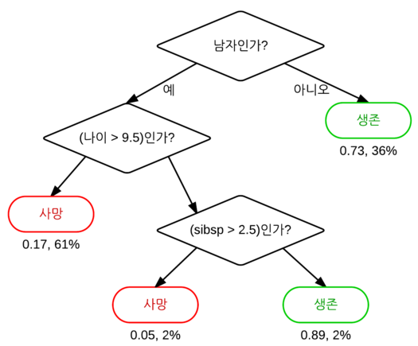

타이타닉호 탐승객의 생존 여부에 관한 의사결정나무

### 의사결정나무 알고리즘

지니 불순도(CART 알고리즘) : 집합에 이질적인 것이 얼마나 섞였는지를 측정하는 지표

정보획득량(C4.5, C5.0) : 정보 이론의 엔트로피의 개념에 근거를 두고 있다.

분산감소(CART) : CART에서 소개된 분산 감소 기법은 목표 변수가 연속적일 경우(회귀 트리)에서 자주 사용된다.

CHAID (CHi-squared Automatic Interaction Detector) : 이 알고리즘은 분류 트리를 계산할 때 다단계 분할을 수행한다.

MARS (Multivariate adaptive regression splines) : 더 많은 수치 데이터를 처리하기 위해 결정 트리를 사용한다.

조건부 추론 트리 (Conditional Inference Trees) : 과적합을 피하기 위해 여러 테스트에 대해 보정 분할 기준으로 비 - 파라미터 테스트를 사용하는 통계 기반의 방법이다. 이 방법은 편견 예측 선택 결과와 가지 치기가 필요하지 않다.

그리고 의사결정나무의 모델을 세우기 위해선 어느 정도 상세화할 것인지 기준을 정해야 합니다. 예를 들어 너무 단순하게 의사결정 나무를 세우면 직관적으로 이해하기는 쉬우나 예측 성능이 떨어질 것이고, 너무 복잡하게 구성된다면 모델을 도출하는데 높은 시스템 사양과 많은 시간이 필요할 뿐 아니라 복잡도가 높아집에 따라 이해하기 어렵기 때문입니다. 그렇다고 해서 분류 성능이 눈에 띄게 높아진다는 보장이 있는 것도 아닙니다. 더군다나 훈련 데이터에 너무 최적화(과적합화) 한다면 훈련 데이터로는 백발백중 분류하겠지만 새로운 입력 데이터에 대한 분류 성능은 오히려 더 떨어지기도 합니다.

그렇다면 의사결정 나무의 의사결정 수준을 어떻게 결정할 것이 적절할까요?

의사결정나무는 이상적인 노드 수를 선택하기 위해 CP(complexity parameter)라는 변수를 사용합니다. CP란 노드를 분리하는데 드는 복잡성을 의미합니다. 최대 CP를 설정함으로써 노드 생성시 복잡성이 CP값 이상이 되면 더 이상 분류 작업을 진행하지 않게 해줍니다. 즉, 분류 에러율이 낮으면서도 노드의 개수가 적은 CP 수준을 찾아 설정함으로써 복잡성을 줄이고, 범용적으로 활용할 수 있는 의사결정 나무 분류기를 만들 수 있습니다.

### 의사결정나무 장단점

| 장점 | 단점 |
| --- | --- |
| 결과를 해석하고 이해하기 쉽다. | 다수의 레벨을 가진 속성 쪽으로 구분하는 경향 |
| 자료를 가공할 필요가 거의 없다. | 모델이 쉽게 과적합화나 과소적합화 |
| 가장 중요한 속성만 사용 | 평행으로 구분하기 때문에 일부 관계를 모델화 하는데 문제 |
| 화이트박스 모델을 사용한다. | 훈련 데이터의 변경이 결정 논리에 큰 영향을 줌 |
| 안정적이다 | 큰 트리는 이해하기 어렵고 직관적일 않음 |
| 다른 복잡한 모델보다 효율성이 높음 |  |

### R을 이용한 실습

- rpart 함수 이용한 의사결정나무

```r
library(rpart)

data(iris)
dt <- rpart(Species ~., data=iris)
table(iris$Species)
```

```
##
##     setosa versicolor  virginica
##         50         50         50
```

```r
dt
```

```
## n= 150
##
## node), split, n, loss, yval, (yprob)
##       * denotes terminal node
##
## 1) root 150 100 setosa (0.33333333 0.33333333 0.33333333)
##   2) Petal.Length< 2.45 50   0 setosa (1.00000000 0.00000000 0.00000000) *
##   3) Petal.Length>=2.45 100  50 versicolor (0.00000000 0.50000000 0.50000000)
##     6) Petal.Width< 1.75 54   5 versicolor (0.00000000 0.90740741 0.09259259) *
##     7) Petal.Width>=1.75 46   1 virginica (0.00000000 0.02173913 0.97826087) *
```

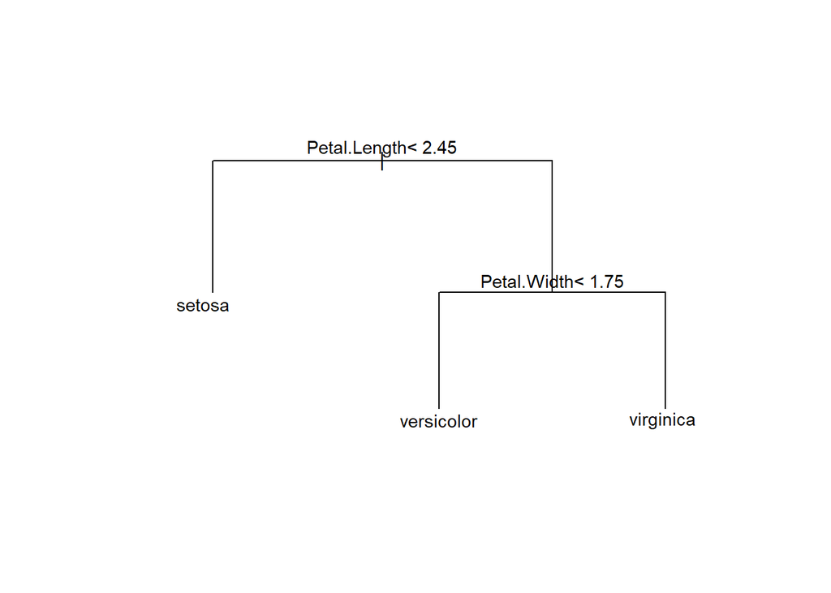

```r
# 총 150개의 자료이며 기본적으로 각 종의 비율을 1/3, 1/3, 1/3
# 2) 기준에 의해 즉 Petal.Length<2.45로 setosa가 판별됨
# setosa 50개 분류
# 6) Petal.width <1.75를 기준으로 54개의 versicolor라 분류 (분류가 잘못된 자료 5개)
# 7) 로 verginica 46개 예측 (분류가 잘못된 자료 1개)

# plot(dt)
plot(dt, compress=TRUE, margin=.2)
# compress로 나무를 좀 더 조밀하게 그릴 수 있다.

text(dt, cex=0.9)
```

```r
# cex는 글자의 크기를 의미

pred.dt<-predict(dt, newdat=iris, type="class")

xtabs(~pred.dt+iris$Species)
```

```
##             iris$Species
## pred.dt      setosa versicolor virginica
##   setosa         50          0         0
##   versicolor      0         49         5
##   virginica       0          1        45
```

- tree 함수를 이용한 의사결정나무

```r
library(tree)

tree.iris <- tree(Species ~., data=iris)
summary(tree.iris)
```

```
##
## Classification tree:
## tree(formula = Species ~ ., data = iris)
## Variables actually used in tree construction:
## [1] "Petal.Length" "Petal.Width"  "Sepal.Length"
## Number of terminal nodes:  6
## Residual mean deviance:  0.1253 = 18.05 / 144
## Misclassification error rate: 0.02667 = 4 / 150
```

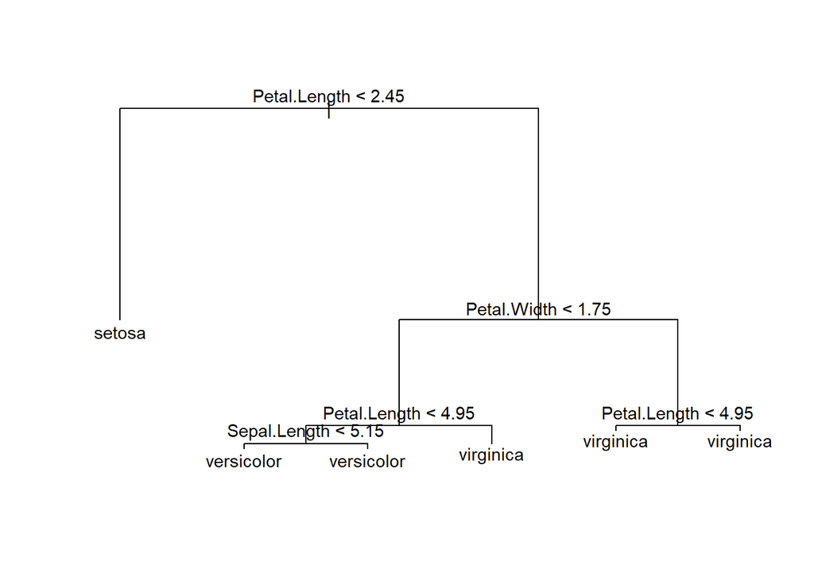

```r
plot(tree.iris)
text(tree.iris, cex=0.9)
```

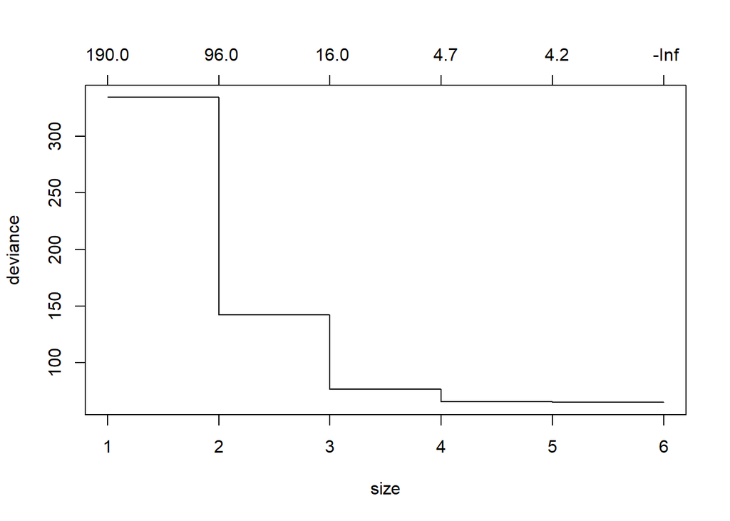

```r
# 과적합화의 문제가 있으므로 가지치기단계가 필요함

cv.tree.out<-cv.tree(tree.iris,FUN=prune.tree, K = 5 )
plot(cv.tree.out)
```

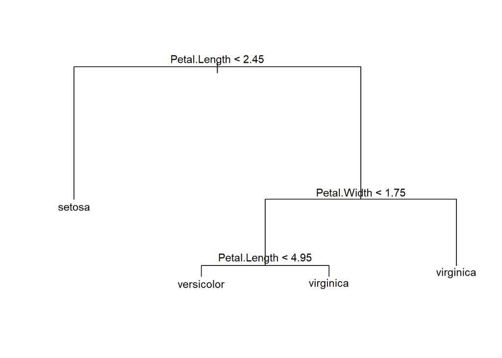

```r
tree.iris2<-prune.tree(tree.iris, best=4)
plot(tree.iris2)
text(tree.iris2, cex=0.9)
```

- ctree 함수를 이용한 의사결정나무

```r
library(party)
ct <- ctree(Species~., data=iris)
ct
```

```
##
##   Conditional inference tree with 4 terminal nodes
##
## Response:  Species
## Inputs:  Sepal.Length, Sepal.Width, Petal.Length, Petal.Width
## Number of observations:  150
##
## 1) Petal.Length <= 1.9; criterion = 1, statistic = 140.264
##   2)*  weights = 50
## 1) Petal.Length > 1.9
##   3) Petal.Width <= 1.7; criterion = 1, statistic = 67.894
##     4) Petal.Length <= 4.8; criterion = 0.999, statistic = 13.865
##       5)*  weights = 46
##     4) Petal.Length > 4.8
##       6)*  weights = 8
##   3) Petal.Width > 1.7
##     7)*  weights = 46
```

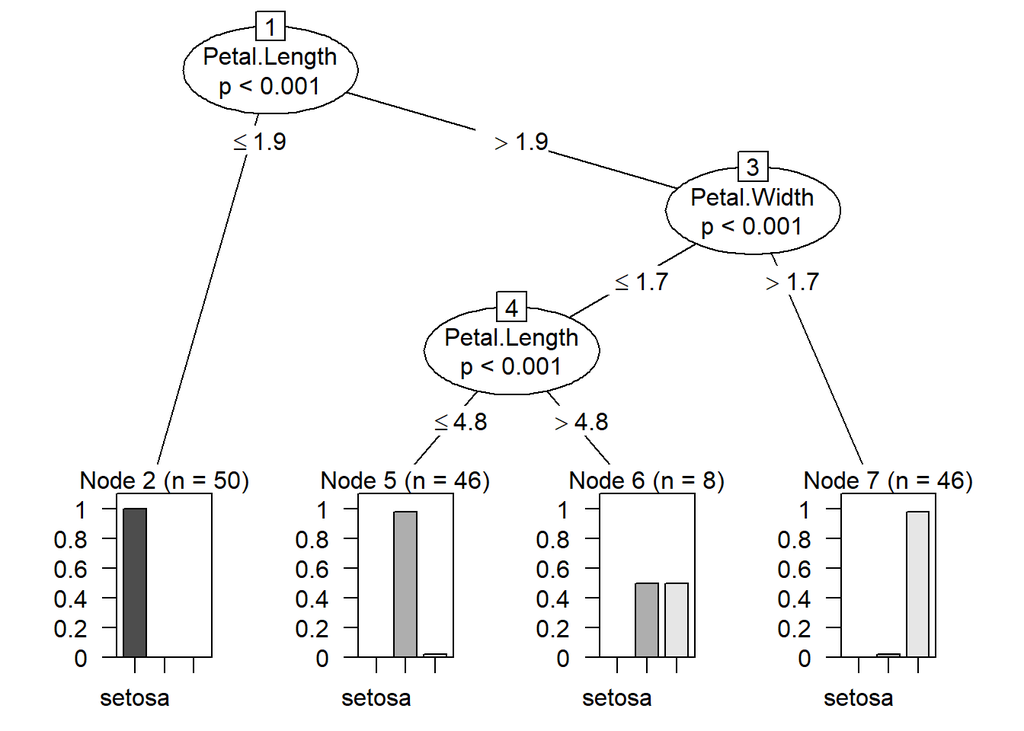

```r
plot(ct)
```

```r
predict(ct, newdata=iris)
```

```
##   [1] setosa     setosa     setosa     setosa     setosa     setosa
##   [7] setosa     setosa     setosa     setosa     setosa     setosa
##  [13] setosa     setosa     setosa     setosa     setosa     setosa
##  [19] setosa     setosa     setosa     setosa     setosa     setosa
##  [25] setosa     setosa     setosa     setosa     setosa     setosa
##  [31] setosa     setosa     setosa     setosa     setosa     setosa
##  [37] setosa     setosa     setosa     setosa     setosa     setosa
##  [43] setosa     setosa     setosa     setosa     setosa     setosa
##  [49] setosa     setosa     versicolor versicolor versicolor versicolor
##  [55] versicolor versicolor versicolor versicolor versicolor versicolor
##  [61] versicolor versicolor versicolor versicolor versicolor versicolor
##  [67] versicolor versicolor versicolor versicolor virginica  versicolor
##  [73] versicolor versicolor versicolor versicolor versicolor versicolor
##  [79] versicolor versicolor versicolor versicolor versicolor versicolor
##  [85] versicolor versicolor versicolor versicolor versicolor versicolor
##  [91] versicolor versicolor versicolor versicolor versicolor versicolor
##  [97] versicolor versicolor versicolor versicolor virginica  virginica
## [103] virginica  virginica  virginica  virginica  versicolor virginica
## [109] virginica  virginica  virginica  virginica  virginica  virginica
## [115] virginica  virginica  virginica  virginica  virginica  versicolor
## [121] virginica  virginica  virginica  virginica  virginica  virginica
## [127] virginica  virginica  virginica  versicolor virginica  virginica
## [133] virginica  versicolor versicolor virginica  virginica  virginica
## [139] virginica  virginica  virginica  virginica  virginica  virginica
## [145] virginica  virginica  virginica  virginica  virginica  virginica
## Levels: setosa versicolor virginica
```

## 랜덤포레스트 분류 모형

Randomforest는 앙상블(Ensemble) 학습을 사용한 모델

앙상블 학습은 주어진 데이터로부터 여러개의 모델을 학습한 다음, 예측 시 여러 모델의 예측 결과들을 종합해 정확도를 높이는 기법

랜덤 포레스트는 두가지 방법을 사용해 다양한 의사결정 나무를 만듬

첫번째, 데이터의 일부를 복원추출로 사용하여 의사결정나무 생성

두번째 노드 나누는 기준에 사용되는 변수를 일부만 사용

랜덤포레스트는 성능이 뛰어난 의사결정나무 하나로 모형을 예측하지 않고 여러개를 사용하여 예측하므로 과적합의 문제가 피해간다.

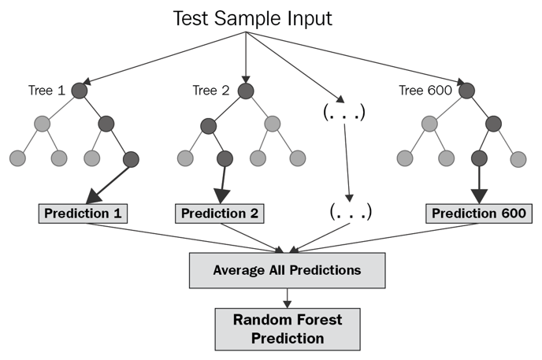

하지만 블랙박스 모형이라 모형의 내부 과정을 이해하기 어렵다.

### R을 이용한 실습

```r
if(!require(randomForest)) install.packages("randomForest"); library(randomForest)
rf.iris <- randomForest(Species~., data=iris, importance=TRUE)

rf.iris
```

```
##
## Call:
##  randomForest(formula = Species ~ ., data = iris, importance = TRUE)
##                Type of random forest: classification
##                      Number of trees: 500
## No. of variables tried at each split: 2
##
##         OOB estimate of  error rate: 4.67%
## Confusion matrix:
##            setosa versicolor virginica class.error
## setosa         50          0         0        0.00
## versicolor      0         47         3        0.06
## virginica       0          4        46        0.08
```

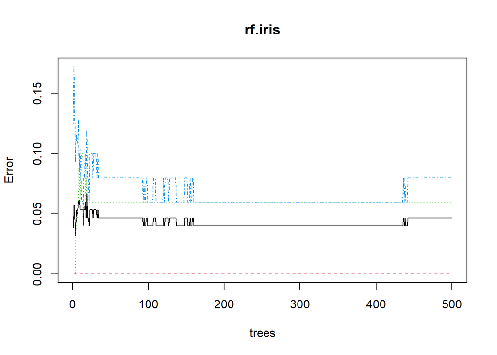

```r
plot(rf.iris) #적절한 ntress를 판단할 수 있다.
```

```r
importance(rf.iris) #변수별 중요도 확인
```

```
##                 setosa versicolor virginica MeanDecreaseAccuracy
## Sepal.Length  6.323896   5.002142   7.68521             9.800493
## Sepal.Width   4.391753   1.298842   2.85377             4.019962
## Petal.Length 22.705290  33.367926  27.50327            33.804666
## Petal.Width  21.877988  31.580910  29.88274            32.427045
##              MeanDecreaseGini
## Sepal.Length         9.027419
## Sepal.Width          2.441709
## Petal.Length        43.480353
## Petal.Width         44.234410
```

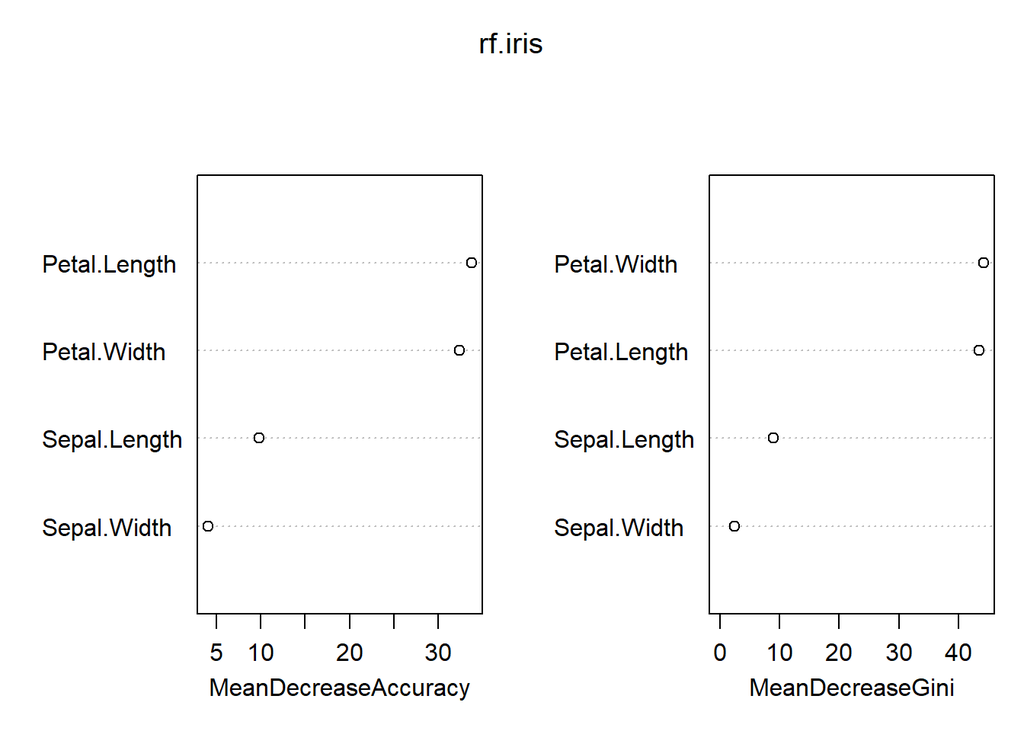

```r
varImpPlot(rf.iris)
```